# Background

Read more here. Using devices such as Jawbone Up, Nike FuelBand, and Fitbit it is now possible to collect a large amount of data about personal activity relatively inexpensively. These type of devices are part of the quantified self movement – a group of enthusiasts who take measurements about themselves regularly to improve their health, to find patterns in their behavior, or because they are tech geeks. One thing that people regularly do is quantify how much of a particular activity they do, but they rarely quantify how well they do it. In this project, your goal will be to use data from accelerometers on the belt, forearm, arm, and dumbell of 6 participants. They were asked to perform barbell lifts correctly and incorrectly in 5 different ways. More information is available from the website [here](http://groupware.les.inf.puc-rio.br/har). (see the section on the Weight Lifting Exercise Dataset).

# Data

The training data for this project are available here: [Training Data](https://d396qusza40orc.cloudfront.net/predmachlearn/pml-training.csv) The test data are available here: [Testing Data](https://d396qusza40orc.cloudfront.net/predmachlearn/pml-testing.csv) The data for this project come from this source: http://groupware.les.inf.puc-rio.br/har. If you use the document you create for this class for any purpose please cite them as they have been very generous in allowing their data to be used for this kind of assignment.

Six young health participants were asked to perform one set of 10 repetitions of the Unilateral Dumbbell Biceps Curl in five different fashions: exactly according to the specification (Class A), throwing the elbows to the front (Class B), lifting the dumbbell only halfway (Class C), lowering the dumbbell only halfway (Class D) and throwing the hips to the front (Class E).

# Objective

The goal of the project is to predict the manner in which they did the exercise. This is the “classe” variable in the training set. You may use any of the other variables to predict with.

### Load packages

```r
library(tidyverse)
library(ggplot2)
library(caret)
library(rpart)
library(rpart.plot)
library(maptree)
library(data.table)
library(forecast)
library(lubridate)
library(rattle)
library(devtools)
library(dplyr)
library(igraph)
library(ggraph)
```

### Load data

```r
train.url <- "https://d396qusza40orc.cloudfront.net/predmachlearn/pml-training.csv"
test.url <- "https://d396qusza40orc.cloudfront.net/predmachlearn/pml-testing.csv"
train <- read.csv(train.url, header = T, sep = ",")
test <- read.csv(test.url, header = T, sep = ",")
```

### Split sub train/test

```r
inSplit <- createDataPartition(train$classe, p = .7 , list = F)
training <- train[inSplit,]
testing <- train[-inSplit,]
```

## Adjust data for machine learning process

- Partition of data into training and testing set, respectively 70%/30%
- Removal of near zero values and manual unnecessary variables

```r
### Filter out garbage data
# Drop columns with NAs
training <- training[, colSums(is.na(training)) == 0]
testing <- testing[, colSums(is.na(testing)) == 0]
## Detect useful data with no nearZero values
nearZero <- nearZeroVar(training, saveMetrics = T) ## All variables have multiple distinct values
nearZero <- rownames(nearZero)[nearZero$nzv == FALSE]
## Remove garbage data
training <- training[, (names(training) %in% nearZero)]
testing <- testing[, (names(testing) %in% nearZero)]
## Manually remove unnecessary variables
training <- training[, -c(1,2,5,6)]
testing <- testing[, -c(1,2,5,6)]
```

### Explore class variable across data set

- Quick identification of the “classe” variable frequencies

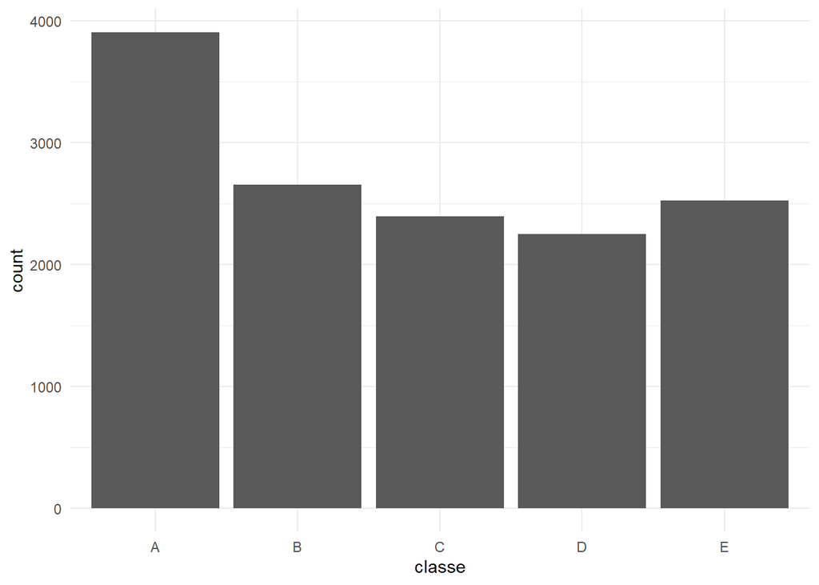

### Apply decision tree model

- Application of decision tree model
- Identification of its accuracy

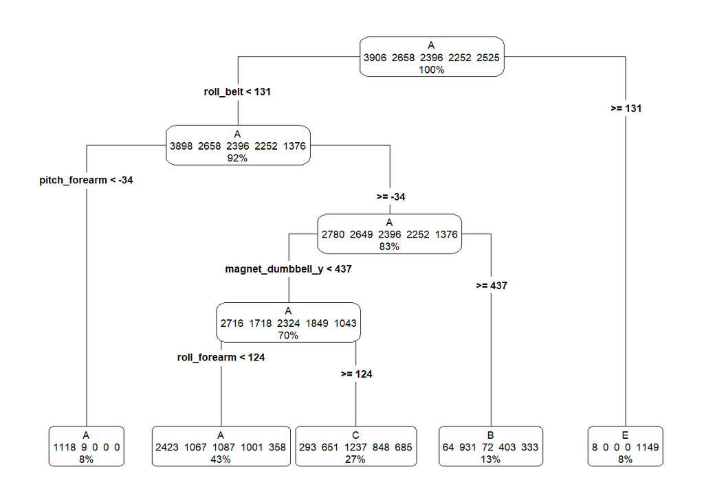

```r
set.seed(123)
dtFit <- train(classe ~ ., data=training, method="rpart")
prp(dtFit$finalModel, type = 4, extra = 101, leaf.round = 1, fallen.leaves = TRUE,
    varlen = 0, tweak = 1)
```

```r
dtPred <- predict(dtFit,testing)
dtConfMatrix <- confusionMatrix(as.factor(testing$classe), dtPred)
dtConfMatrix
```

```
## Confusion Matrix and Statistics
##
##           Reference
## Prediction    A    B    C    D    E
##          A 1528   31  109    0    6
##          B  493  371  275    0    0
##          C  499   37  490    0    0
##          D  440  177  347    0    0
##          E  163  162  275    0  482
##
## Overall Statistics
##
##                Accuracy : 0.4879
##                  95% CI : (0.475, 0.5007)
##     No Information Rate : 0.5307
##     P-Value [Acc > NIR] : 1
##
##                   Kappa : 0.3296
##
##  Mcnemar's Test P-Value : NA
##
## Statistics by Class:
##
##                      Class: A Class: B Class: C Class: D Class: E
## Sensitivity            0.4893  0.47686  0.32754       NA  0.98770
## Specificity            0.9471  0.84962  0.87788   0.8362  0.88883
## Pos Pred Value         0.9128  0.32572  0.47758       NA  0.44547
## Neg Pred Value         0.6212  0.91424  0.79296       NA  0.99875
## Prevalence             0.5307  0.13220  0.25421   0.0000  0.08292
## Detection Rate         0.2596  0.06304  0.08326   0.0000  0.08190
## Detection Prevalence   0.2845  0.19354  0.17434   0.1638  0.18386
## Balanced Accuracy      0.7182  0.66324  0.60271       NA  0.93827
```